# Modeling temperatures and sales

## Modeling monthly revenue

In this second example let's try to forecast some sales figures with a very simple model

```python
df = pd.read_csv(search_import_file('sales_data_sample','csv'), encoding="ISO-8859-1")
```

```python
dfs = df[['ORDERNUMBER','SALES','MONTH_ID','YEAR_ID']]
dfs.set_index('ORDERNUMBER', inplace = True)
dfs.sort_index()

drop = dfs[['MONTH_ID','YEAR_ID']].reset_index()
drop = drop.drop_duplicates('ORDERNUMBER')
drop.set_index('ORDERNUMBER', inplace = True)


group = dfs.groupby('ORDERNUMBER')['SALES'].sum().to_frame()
group = group.join(drop[['MONTH_ID','YEAR_ID']], how='inner')
```

```python
dic = {}
for i in range(len(group['YEAR_ID'])):
    d = date(group['YEAR_ID'].values[i], group['MONTH_ID'].to_frame().values[i], 1)
    dic[group['YEAR_ID'].index[i]] = d

dates = pd.DataFrame.from_dict(dic, orient='index')
dates = dates.rename(index=str, columns={0: "Date",})

#group['Date'] = pd.to_datetime(dates)
```

```python
dates = dates.reset_index()
dates = dates.rename(columns={'index': "ORDERNUMBER",})
dates.ORDERNUMBER = dates.ORDERNUMBER.astype(int)
dates['Date'] = pd.to_datetime(dates['Date'], format="%Y/%m/%d", errors='ignore')

dates.head()
#dates.set_index('ORDERNUMBER')
```

|  | ORDERNUMBER | Date |
| --- | --- | --- |
| 0 | 10240 | 2004-04-01 |
| 1 | 10241 | 2004-04-01 |
| 2 | 10242 | 2004-04-01 |
| 3 | 10243 | 2004-04-01 |
| 4 | 10244 | 2004-04-01 |

```python
group = group.reset_index()
group.ORDERNUMBER = group.ORDERNUMBER.astype(int)
```

```python
group = pd.merge(group, dates, how='inner', on='ORDERNUMBER')
```

```python
group.set_index('Date', inplace = True)
group.drop(['MONTH_ID', 'YEAR_ID', 'ORDERNUMBER'], axis = 1, inplace=True)
```

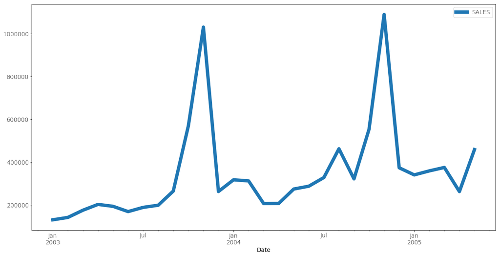

```python
group.reset_index().groupby("Date").sum().plot(figsize=(20,10));
```

```python
sales = group.reset_index().groupby("Date").sum()
fixed = sales[sales.index < '2004-01-01']
prediction = sales[sales.index >= '2004-01-01']

prediction = pd.Series()
prediction = prediction.append(pd.Series(fixed.iloc[-1,0], index=[fixed.iloc[-1].name+timedelta(days=31)]))

for i in range(11):
    prediction = prediction.append(pd.Series(fixed.iloc[i+1,0]+100000, index=[prediction.index[i]+timedelta(days=31)]))
```

```python
prediction2 = pd.Series()
prediction2 = prediction2.append(pd.Series(prediction.iloc[-1], index=[prediction.index[-1]+timedelta(days=31)]))

for i in range(11):
    prediction2 = prediction2.append(pd.Series(prediction.iloc[i+1]+100000, index=[prediction2.index[i]+timedelta(days=31)]))
```

```python
result = pd.concat([fixed,prediction])
result.index

result.name = 'prediction'
prediction.name = 'prediction'

result = pd.Series(index=result.index)
result = result.append(fixed.iloc[:,0])
result = result.append(prediction)
result = result.append(prediction2)

result.dropna()
```

```
2003-01-01     129753.60
2003-02-01     140836.19
2003-03-01     174504.90
2003-04-01     201609.55
2003-05-01     192673.11
2003-06-01     168082.56
2003-07-01     187731.88
2003-08-01     197809.30
2003-09-01     263973.36
2003-10-01     568290.97
2003-11-01    1029837.66
2003-12-01     261876.46
2004-01-01     261876.46
2004-02-01     240836.19
2004-03-03     274504.90
2004-04-03     301609.55
2004-05-04     292673.11
2004-06-04     268082.56
2004-07-05     287731.88
2004-08-05     297809.30
2004-09-05     363973.36
2004-10-06     668290.97
2004-11-06    1129837.66
2004-12-07     361876.46
2005-01-07     361876.46
2005-02-07     340836.19
2005-03-10     374504.90
2005-04-10     401609.55
2005-05-11     392673.11
2005-06-11     368082.56
2005-07-12     387731.88
2005-08-12     397809.30
2005-09-12     463973.36
2005-10-13     768290.97
2005-11-13    1229837.66
2005-12-14     461876.46
dtype: float64
```

Let's have a rough approximation of how well we fit the data with the model by plotting it

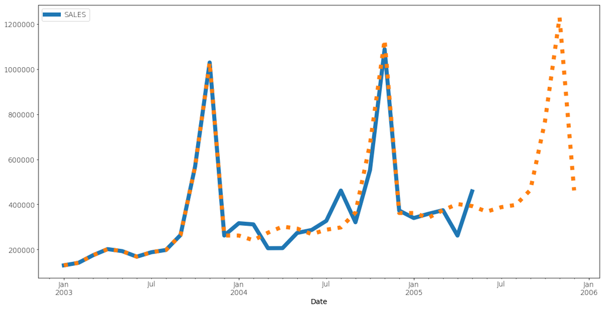

```python
group.reset_index().groupby("Date").sum().plot(figsize=(20,10));
result.dropna().plot(figsize=(20,10), linestyle='dotted');
```

The figure above pictures the real data in blue and the approximation in orange. It has the advantage of being simple to code but it clearly overfits 2003's data. The christmas seasonality is however accurately represented here.